# StatComp21003 homework

## Answer

### 9.3

选取proposal distribution为标准正态分布$N(X_t, \sigma^2)$，其与目标分布$Cauchy(1,0)$具有相同支撑，通常能够满足正则条件。则利用Metropolis-Hastings sampler生成标准柯西分布随机数的R代码如下所示

```r
#柯西分布密度
f <- function(x){
  fx <- 1 / (pi*(1+x^2))
  return(fx)
}

set.seed(1193)
m <- 1e4
x <- numeric(m)
x[1] <- rnorm(1)
k <- 0#记录拒绝次数
u <- runif(m)

#生成马氏链
for(i in 2:m){
  xt <- x[i-1]
  y <- rnorm(1, xt, 1)
  num <- f(y) * dnorm(xt, y, 1)
  den <- f(xt) * dnorm(y, xt, 1)
  r <- num / den
  if(u[i] <= r){
    x[i] <- y
  }else{
    x[i] <- xt
    k <- k+1
  }
}

#比较MH和真实柯西分布的分位数
index <- c(1001:m)
yMH <- x[index]
ps <- seq(0.1, 0.9, 0.1)
result <- rbind(quantile(yMH, ps), qcauchy(ps))#绘制结果表格
dimnames(result)[[1]] <- c("Metropolis-Hastings", "True")
kable(result, caption = "表1.1：分位数对比结果")
```

表1.1：分位数对比结果

|  | 10% | 20% | 30% | 40% | 50% | 60% | 70% | 80% | 90% |
| --- | --- | --- | --- | --- | --- | --- | --- | --- | --- |
| Metropolis-Hastings | -2.593181 | -1.271254 | -0.6557718 | -0.2913120 | 0.0345928 | 0.3424151 | 0.7466429 | 1.401148 | 3.031550 |
| True | -3.077684 | -1.376382 | -0.7265425 | -0.3249197 | 0.0000000 | 0.3249197 | 0.7265425 | 1.376382 | 3.077684 |

从表1.1可以看到，利用Metropolis-Hastings sampler生成的柯西分布与真实柯西分布二者分位数较为接近。

### 9.8

由题知该二元密度$f(x,y),\quad x=0,1,...,n,0\leq y\leq 1$的条件分布分别为$Binomial(n,y)$和$Beta(x+a, n-x+b)$。则可以利用Gibbs sampler生成该二元密度的随机数，R代码如下所示

```r
#Gibbs sampler function, 固定n=10, a=1, b=2
Gibbs <- function(N, x0, y0, n=10, a=1, b=2){
  X <- matrix(nrow = N, ncol = 2)

  #初始化
  x <- x0
  y <- y0
  X[1,] <- c(x, y)

  for(i in 2:N){
    y <- X[i-1, 2]
    X[i, 1] <- rbinom(1, n, y)#x|y为Binomial(n,y)
    x <- X[i, 1]
    X[i, 2] <- rbeta(1, x+a, n-x+b)#y|x为Beta(x+a, n-x+b)
  }
  return(X)
}

set.seed(1198)
n <- 10
a <- 1
b <- 2
N <- 5000
x0 <- 0.5*n
y0 <- (x0+a) / (n+a+b)#初始化
X <- Gibbs(N, x0, y0)
burn <- 1000
XGibbs <- X[(burn+1):N,]
#plot(XGibbs, cex=0.5, xlab="x", ylab="y")#XY散点图
```

### Discussion

For each of the above exercise, use the Gelman-Rubin method to monitor convergence of the chain, and run the chain until it converges approximately to the target distribution according to $\hat{R}<1.2$.

- **exercise 9.3**

```r
#生成柯西分布马氏链
cauchy.chain <- function(x0, m){
  x <- numeric(m)
  x[1] <- x0
  k <- 0#记录拒绝次数
  u <- runif(m)

  #生成马氏链
  for(i in 2:m){
    xt <- x[i-1]
    y <- rnorm(1, xt, 1)
    num <- dcauchy(y) * dnorm(xt, y, 1)
    den <- dcauchy(xt) * dnorm(y, xt, 1)
    r <- num / den
    if(u[i] <= r){
      x[i] <- y
    }else{
      x[i] <- xt
      k <- k+1
    }
  }

  return(x)
}

#Gelman-Rubin方法计算Rhat
Gelman.Rubin <- function(psi){
  # psi[i,j] is the statistic psi(X[i,1:j]) for chain in i-th row of X
  psi <- as.matrix(psi)
  n <- ncol(psi)
  k <- nrow(psi)

  psi.means <- rowMeans(psi)     #row means
  B <- n * var(psi.means)        #between variance est.
  psi.w <- apply(psi, 1, "var")  #within variances
  W <- mean(psi.w)               #within est.
  v.hat <- W*(n-1)/n + (B/n)     #upper variance est.
  r.hat <- v.hat / W             #G-R statistic
  return(r.hat)
}

set.seed(113)
k <- 4#chain的个数
m <- 15000#chain的长度
burn <- 1000
x0 <- c(-10, -5, 5, 10)#初始值

# X <- matrix(nrow = k, ncol = m)
# for(i in 1:k)
#   X[i,] <- cauchy.chain(x0[i], m)
#
# #计算检验统计量psi
# psi <- t(apply(X, 1, cumsum))
# for(i in 1:nrow(psi))
#   psi[i,] <- psi[i,] / (1:ncol(psi))
#
# #绘制psi
# par(mfrow=c(2, 2))
# for(i in 1:k)
#   plot(psi[i, (burn+1):m], type="l", xlab=i, ylab=bquote(psi))
#
# #绘制Rhat
# par(mfrow=c(1, 1))
# rhat <- numeric(m)
# for(j in (burn+1):m)
#   rhat[j] <- Gelman.Rubin(psi[,1:j])
# plot(rhat[(burn+1):m], type="l", xlab="", ylab="R")
# abline(h=1.2, lty=2)
```

- **exercise 9.8**

```r
set.seed(98)
k <- 3#chain的个数
m <- 15000#chain的长度
burn <- 1000
n <- 10
a <- 1
b <- 2
x0 <- c(0, 5, 10)#初始值
y0 <- (x0+a) / (n+a+b)#初始化

X <- matrix(nrow = k, ncol = m)
Y <- matrix(nrow = k, ncol = m)
# for(i in 1:k){
#   XY <- t(Gibbs(m, x0[i], y0[i]))
#   X[i,] <- XY[1,]
#   Y[i,] <- XY[2,]
# }

#对X的边缘分布利用Gelman-Rubin方法观测收敛性
#计算检验统计量psi
psi <- t(apply(X, 1, cumsum))
for(i in 1:nrow(psi))
  psi[i,] <- psi[i,] / (1:ncol(psi))

#绘制psi
# par(mfrow=c(2, 2))
# for(i in 1:k)
#   plot(psi[i, (burn+1):m], type="l", xlab=i, ylab=bquote(psi))
```

```r
# #绘制Rhat
# par(mfrow=c(1, 1))
# rhat <- numeric(m)
# for(j in (burn+1):m)
#   rhat[j] <- Gelman.Rubin(psi[,1:j])
# plot(rhat[(burn+1):m], type="l", xlab="", ylab="R")
# abline(h=1.2, lty=2)
```

```r
# #对Y的边缘分布利用Gelman-Rubin方法观测收敛性
# #计算检验统计量psi
# psi <- t(apply(Y, 1, cumsum))
# for(i in 1:nrow(psi))
#   psi[i,] <- psi[i,] / (1:ncol(psi))
#
# #绘制psi
# par(mfrow=c(2, 2))
# for(i in 1:k)
#   plot(psi[i, (burn+1):m], type="l", xlab=i, ylab=bquote(psi))
```

```r
# #绘制Rhat
# par(mfrow=c(1, 1))
# rhat <- numeric(m)
# for(j in (burn+1):m)
#   rhat[j] <- Gelman.Rubin(psi[,1:j])
# plot(rhat[(burn+1):m], type="l", xlab="", ylab="R")
# abline(h=1.2, lty=2)
```

## A-21003-2021-11-18

## Question

Exercises 11.3 and 11.5 (pages 353-354, Statistical Computing with R).

Suppose $T_1, ...,T_n$ are i.i.d. samples drawn from the exponential distribution with expectation $\lambda$. Those values greater than $\tau$ are not observed due to right censorship, so that the observed values are $Y_i=T_iI(T_i \leq \tau) + \tau I(T_i>\tau),\quad i=1,...,n$. Suppose $\tau = 1$ and the observed $Y_i$ values are as follows:
$$0.54, 0.48, 0.33, 0.43, 1.00, 1.00, 0.91, 1.00, 0.21, 0.85$$
Use the E-M algorithm to estimate $\lambda$, compare your result with the observed data MLE (note:$Y_i$ follows a mixture distribution).

## Answer

### 11.3

(a)首先计算该级数的第$k$项，为防止$k$过大时溢出利用先取对数再求指数的方式计算

```r
Termk <- function(a, k){
  d <- length(a)
  return(
    (-1)^k * gamma((d+1)/2) / ((2*k+1)*(2*k+2)) * exp(-lgamma(k+1) - k*log(2) + (2*k+2)*log(norm(a, type = "2")) + lgamma(k+3/2) - lgamma(k+d/2+1))
  )
}
```

(b)进一步利用向量化运算求和

```r
SumTerm <- function(a){
  K <- c(0:200)#求和至k=200
  return(sum(Termk(a, K)))
}
```

(c)当$a=(1, 2)^T$时级数和

```r
a <- c(1, 2)
SumTerm(a)
```

```
## [1] 1.532164
```

结果约为1.53。

### 11.5

首先求解Exercise 11.5

```r
ck <- function(a, k){
  sqrt((a^2*k) / (k+1-a^2))
}#积分限

g <- function(u, k){
  (1 + u^2/k)^(-(k+1)/2)
}#被积函数

intg <- function(ck, k){
  integrate(g, lower = 0, upper = ck,
            k = k)
}#积分项

bk <- function(k){
  2/sqrt(pi*k)*exp(lgamma((k+1)/2) - lgamma(k/2))
}#常数项

f <- function(a, k){
  bk(k)*intg(ck(a, k), k)$value - bk(k-1)*intg(ck(a, k-1), k-1)$value
}#转化为求f(a ,k)=0

#求根
eps <- .Machine$double.eps^0.25
root_115 <- function(k){
  uniroot(f, interval = c(eps, 2), k=k)$root
}
```

计算Exercise 11.4中的$A(k)$

```r
S <- function(a,k){
  pt(q=sqrt(a^2*k / (k+1-a^2)), df=k, lower.tail = F)
}

obj <- function(a, k){
  S(a, k) - S(a, k-1)
}

root_114 <- function(k){
  uniroot(obj, interval = c(eps, 2), k=k)$root
}
```

取$k=4:25, 100, 500, 1000$对比二者的解

```r
ks <- c(4:25, 100, 500, 1000)
result <- matrix(nrow = length(ks), ncol = 3)
result[,1] <- ks
for(i in 1:length(ks)){
  result[i, 2:3] <- c(root_115(ks[i]), root_114(ks[i]))
}
dimnames(result)[[2]] <- c("k", "ex11.5", "ex11.4")
kable(result, caption = "表2.1：ex11.5与ex11.4求根结果对比")
```

表2.1：ex11.5与ex11.4求根结果对比

| k | ex11.5 | ex11.4 |
| --- | --- | --- |
| 4 | 1.492103 | 1.492103 |
| 5 | 1.533556 | 1.533556 |
| 6 | 1.562744 | 1.562744 |
| 7 | 1.584430 | 1.584430 |
| 8 | 1.601185 | 1.601185 |
| 9 | 1.614521 | 1.614521 |
| 10 | 1.625390 | 1.625390 |
| 11 | 1.634419 | 1.634419 |
| 12 | 1.642038 | 1.642038 |
| 13 | 1.648554 | 1.648554 |
| 14 | 1.654190 | 1.654190 |
| 15 | 1.659114 | 1.659114 |
| 16 | 1.663452 | 1.663452 |
| 17 | 1.667304 | 1.667304 |
| 18 | 1.670745 | 1.670745 |
| 19 | 1.673840 | 1.673840 |
| 20 | 1.676637 | 1.676637 |
| 21 | 1.679178 | 1.679178 |
| 22 | 1.681496 | 1.681496 |
| 23 | 1.683620 | 1.683620 |
| 24 | 1.685572 | 1.685572 |
| 25 | 1.687373 | 1.687373 |
| 100 | 1.720608 | 1.720608 |
| 500 | 1.729756 | 1.729755 |
| 1000 | 1.730907 | 1.730908 |

从表2.1可以看到，二者求解结果是一致的。

### Discussion

Suppose $T_1, ...,T_n$ are i.i.d. samples drawn from the exponential distribution with expectation $\lambda$. Those values greater than $\tau$ are not observed due to right censorship, so that the observed values are $Y_i=T_iI(T_i \leq \tau) + \tau I(T_i>\tau),\quad i=1,...,n$. Suppose $\tau = 1$ and the observed $Y_i$ values are as follows:
$$0.54, 0.48, 0.33, 0.43, 1.00, 1.00, 0.91, 1.00, 0.21, 0.85$$
Use the E-M algorithm to estimate $\lambda$, compare your result with the observed data MLE (note:$Y_i$ follows a mixture distribution).

**solution:** We know that $Y_i=T_iI(T_i \leq \tau) + \tau I(T_i>\tau)$在$\tau$follows a mixture distribution. When $T_i \leq \tau$, $Y_i \sim \operatorname{Exp}(\frac{1}{\lambda})$, when$T_i>\tau$, $Y_i=\tau$and $P(Y_i=\tau)=e^{-\frac{\tau}{\lambda}}$, denote $n_{\tau}$ the number of those values greater than $\tau$, then the observed data likelihood can be expressed as
$$L(\lambda|n_{\tau})=\prod_{i=1}^{n-n_{\tau}} \frac{1}{\lambda} e^ {-\frac{y_i}{\lambda}}\prod_{i=1}^{n_{\tau}}e^{-\frac{\tau}{\lambda}}=\frac{1}{\lambda^{n-n_\tau}}e^{-\frac{\sum_{i=1}^{n} y_i}{\lambda}},$$
so the MLE for observed data is$\frac{\sum_{i=1}^{n} y_i}{n-n_\tau}$. Complete data likelihood is
$$L(\lambda|\mathbf{y})=\prod_{i=1}^{n} \frac{1}{\lambda} \exp \left(-y_{i} / \lambda\right)$$
Denote $\delta_i=1$if $y_i \leq \tau$ and $\delta_i=0$ if $y_i$ is censored at $\tau$. For the censored data, denote the complete data is $t_i$. The E-step is
$$\mathbb{E}_{\hat{\lambda}_0}\left[L(\lambda|\mathbf{y}) \mid \delta_i \right]=\mathbb{E}_{\hat{\lambda}_0}\left\{-n \log \lambda-\frac{1}{\lambda}\left[\sum_{i=1}^{n} \delta_{i} y_{i}+\left(1-\delta_{i}\right) t_{i}\right] \mid \delta_i\right\}$$
Use the memoryless property of the exponential distribution, we can get $\mathbb{E}_{\hat{\lambda}_0}\left[t_i \mid \delta_i \right]=\tau + \hat{\lambda}_0$, so for the E-step we have
$$\mathbb{E}_{\hat{\lambda}_0}\left[L(\lambda|\mathbf{y}) \mid \delta_i \right]=-n \log \lambda-\frac{1}{\lambda}\left[\sum_{i=1}^{n} \delta_{i} y_{i}+\left(1-\delta_{i}\right) (\tau + \hat{\lambda}_0)\right],$$
maximize the above function to execute the M-step
$$\hat{\lambda}_1=\frac{1}{n}\left[\sum_{i=1}^{n} \delta_{i} y_{i}+\left(1-\delta_{i}\right) (\tau + \hat{\lambda}_0)\right]=\frac{1}{n}\left[\sum_{i=1}^{n}y_i+n_{\tau}\hat{\lambda}_0\right],$$
The converged $\lambda$ estimate is the solution of the following equation
$$\lambda=\frac{1}{n}\left[\sum_{i=1}^{n}y_i+n_{\tau}\lambda\right] \Rightarrow \lambda=\frac{\sum_{i=1}^{n}y_i}{n-n_\tau}$$
which is the same as the observed data MLE.

Use EM algorithm to solve MLE of $\lambda$.

```r
y <- c(0.54, 0.48, 0.33, 0.43, 1.00, 1.00, 0.91, 1.00, 0.21, 0.85)
lambda0 <- 0.5

EMlambda <- function(y, lambda){
  N <- 10000
  tol <- .Machine$double.eps^0.5
  n <- length(y)
  nt <- sum(y==1)

  for(i in 1:N){
    total <- sum(y)
    lambda_old <- lambda
    lambda <- (total + nt*lambda_old) / n

    if(abs(lambda - lambda_old)/lambda_old <tol) break
  }

  return(lambda)
}

EMlambda(y, lambda0)
```

```
## [1] 0.9642857
```

Using EM algorithm we get the estimation of $\lambda$ is about 0.964.

## A-21003-2021-11-25

## Question

Exercises 1 and 5 (page 204, Advanced R)

Exercises 1 and 7 (page 214, Advanced R)

## Answer

### 1.1

在第一个`lapply`语句中`trims`的每个元素被显式地传递给了`mean`函数的第二个参数。而在第二个`lapply`语句中，`mean`函数的第一个参数经由位置匹配把`lapply`的第三个参数传给了它。二者得到结果实际是等价的。

### 1.5

```r
rsq <- function(mod) summary(mod)$r.squared
```

- 对ex3中的模型

```r
formulas <- list(
  mpg ~ disp,
  mpg ~ I(1 / disp),
  mpg ~ disp + wt,
  mpg ~ I(1 / disp) + wt
)

fit3 <- lapply(formulas, lm, data = mtcars)
sapply(fit3, rsq)
```

```
## [1] 0.7183433 0.8596865 0.7809306 0.8838038
```

- 对ex4中的模型

```r
bootstraps <- lapply(1:10, function(i) {
  rows <- sample(1:nrow(mtcars), rep = TRUE)
  mtcars[rows, ]
})

fit4 <- lapply(bootstraps, lm, formula = mpg ~ disp)
sapply(fit4, rsq)
```

```
##  [1] 0.7638473 0.7123009 0.8170350 0.6959773 0.7829012 0.8556576 0.7695607
##  [8] 0.6496155 0.7713120 0.6990634
```

### 2.1

(a)对数值型数据框

```r
dt <- as.data.frame(matrix(1:9, nrow = 3))
vapply(dt, sd, numeric(1))
```

```
## V1 V2 V3
##  1  1  1
```

(b)对混合型数据框，通过嵌套使用`vapply`两次

```r
#以iris数据集为例
vapply(iris[vapply(iris, is.numeric, logical(1))], sd, numeric(1))
```

```
## Sepal.Length  Sepal.Width Petal.Length  Petal.Width
##    0.8280661    0.4358663    1.7652982    0.7622377
```

### 2.7

- 实现`sapply()`的多核版本`mcsapply()`

参照R中`sapply()`利用`lapply()`实现的方法，类似地可以实现`mcsapply()`

```r
# library(parallel)
# cores <-  detectCores()
mcsapply <- function(X, FUN, ..., simplify = TRUE, USE.NAMES = TRUE){
  FUN <- match.fun(FUN)
  answer <- mclapply(X = X, FUN = FUN, ...)
  if (USE.NAMES && is.character(X) && is.null(names(answer)))
      names(answer) <- X
  if (!identical(simplify, FALSE) && length(answer))
      simplify2array(answer, higher = (simplify == "array"))
  else answer
}
```

而由于`vapply()`并未基于`lapply()`，因此难以实现它的并行版本`mcvapply()`。

## A-21003-2021-12-02

## Question

Write an Rcpp function for Exercise 9.8 (page 278, Statistical Computing with R).

## Answer

由题知该二元密度$f(x,y),\quad x=0,1,...,n,0\leq y\leq 1$的条件分布分别为$Binomial(n,y)$和$Beta(x+a, n-x+b)$。利用Gibbs sampler生成该二元密度的随机数

- R function

```r
#Gibbs sampler function, 固定n=10, a=1, b=2
#R function for ex9.8
gibbsR <- function(N, x0, y0, n=10, a=1, b=2){
  X <- matrix(nrow = N, ncol = 2)

  #初始化
  x <- x0
  y <- y0
  X[1,] <- c(x, y)

  for(i in 2:N){
    y <- X[i-1, 2]
    X[i, 1] <- rbinom(1, n, y)#x|y为Binomial(n,y)
    x <- X[i, 1]
    X[i, 2] <- rbeta(1, x+a, n-x+b)#y|x为Beta(x+a, n-x+b)
  }
  return(X)
}
```

- Cpp function

```r
#Cpp function for ex9.8
library(Rcpp)
cppFunction('NumericMatrix gibbsC(int N, double x0, double y0, int n=10, int a=1, int b=2){
  NumericMatrix mat(N, 2);
  double x = x0, y = y0;
  mat(0, 0) = x;
  mat(0, 1) = y;

  for(int i = 1; i < N; i++){
    y = mat(i-1, 1);
    mat(i, 0) = rbinom(1, n, y)[0];
    x = mat(i, 0);
    mat(i, 1) = rbeta(1, x+a, n-x+b)[0];
  }
  return mat;
}')
```

- Compare the corresponding generated random numbers with pure R language using the function `qqplot`.

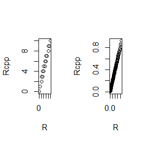

```r
set.seed(1198)
#初始化
n <- 10
a <- 1
b <- 2
N <- 5000
x0 <- 0.5*n
y0 <- (x0+a) / (n+a+b)

Chain_R <- gibbsR(N, x0, y0)
Chain_Cpp <- gibbsC(N, x0, y0)

##qqplot compare for x
par(mfrow=c(1,2))
burn <- 1000
x_R <- as.numeric(Chain_R[(burn+1):N,1])
x_Cpp <- as.numeric(Chain_Cpp[(burn+1):N,1])
p <- ppoints(100)
qqplot(quantile(x_R, p), quantile(x_Cpp, p), xlab = "R", ylab = "Rcpp")
##qqplot compare for y
y_R <- as.numeric(Chain_R[(burn+1):N,2])
y_Cpp <- as.numeric(Chain_Cpp[(burn+1):N,2])
qqplot(quantile(y_R, p), quantile(y_Cpp, p), xlab = "R", ylab = "Rcpp")
```

- Campare the computation time of the two functions with the function `microbenchmark`.

```r
library(microbenchmark)
ts <- microbenchmark(gR=gibbsR(N, x0, y0), gC=gibbsC(N, x0, y0))
summary(ts)[,c(1,3,5,6)]
```

```
##   expr       lq   median       uq
## 1   gR 19.38455 25.49945 27.02745
## 2   gC  1.32735  1.34045  1.40690
```

结论：(1)从qq图可以看到，利用R和Rcpp生成的随机数x, y分布相同。(2)从计算时间来看，利用Rcpp生成随机数的速度更快。